# Econometria Aplicada à Finanças Aula 10

Mestrado Profissional em Administração

Prof. Washington Santos da Silva

IFMG - Campus Formiga

21 de outubro de 2025

## Diário de Bordo

**O que vimos até o momento?**

- Aula 1 ✅
  - Apresentação da Disciplina ✅
  - Introdução ao RStudio ✅
  - Configurando o Projeto da Disciplina ✅
  - Conheça e Utilize o Terminal Git Bash ✅
- Aula 2 ✅
  - Git e GitHub: Visão Geral ✅
  - Introdução ao Sistema: Visão Geral ✅
  - Linguagem R: Visão Geral ✅
  - Sessão Prática 1 ✅
- Aula 3 ✅
  - Minicurso Intensivo: Teoria da Probabilidade - Parte 1 ✅
    - Introdução à Teoria da Probabilidade ✅
    - Variáveis Aleatórias e Distribuições de Probabilidade ✅
    - Distribuições Conjunta, Marginal e Condicional ✅
    - Independência de Variáveis Aleatórias ✅
- Aula 4 ✅
  - Minicurso Intensivo: Teoria da Probabilidade - Parte 2 ✅
    - Conceitos Básicos: Revisão ✅
    - Momentos de Distribuições de Probabilidade Univariadas ✅
    - Funções de Variáveis Aleatórias ✅
    - Fundamentos de Distribuições de Probabilidade Multivariadas ✅
    - Cálculo Diferencial e Integral em R
- Aula 5 ✅
  - Minicurso Intensivo: Teoria da Probabilidade - Parte 3 ✅
  - Distribuições de Variáveis Aleatórias Discretas ✅
  - Distribuições de Variáveis Aleatórias Contínuas ✅
  - Distribuições de Vetores Aleatórios ✅
  - A Ponte entre Probabilidade e Estatística/Econometria ✅
- Aula 6 ✅
  - Minicurso Intensivo: Métodos de Inferência Estatística I ✅
  - Estimação de Parâmetros: O Básico ✅
  - Métodos de Estimação de Parâmetros ✅
  - Estimação pode Intervalos de Confiança ✅
- Aula 7 ✅
  - Minicurso Intensivo: Métodos de Inferência Estatística II ✅
  - Propriedades dos Estimadores de Máxima Verossimilhança ✅
  - Testes de Hipóteses (ou de Significância) ✅
- Aula 8 ✅
  - Modelo de Regressão Linear: Fundamento ✅
  - Modelo de Regressão Linear Simples ✅
    - Hipóteses
    - Estimação
    - Inferência
    - Diagnóstico gráfico dos resíduos
- Aula 9 ✅
  - Modelo de Regressão Linear Múltipla ✅
    - Forma matricial do modelo
    - Hipóteses
    - Estimação
    - Inferência
  - Multicolinearidade
    - Descrição
    - Fator de inflação da variância
    - Técnicas modernas
  - H3: Exogeneidade
    - Descriçào
    - Violação: endogeneidade
    - Viés de variável omitida
    - H1: Especificação incorreta

## Nesta Aula

**Tópicos**

- Modelo de Regressão Linear Múltipla
  - H4: homocedasticidade (variância do erro constante)
    - Violação: heterecedasticidade
    - Testes de heterocedasticidade
    - Convivendo com a heterocedasticidade
  - H5: ausência de correlação dos erros
    - Violação: autocorrelação
    - Testes de autocorrelação
    - Convivendo com a autocorrelação

**Diretrizes para Aulas Mais Produtivas**

⌨️ **Código com método:**

95% dos erros são evitáveis com:

- Respeitar a sequência lógica de etapas
- Revisão antes de pedir ajuda
- Atenção na digitação

🤝 **Inteligência colaborativa:**

- Compartilhe conhecimento
- Resolva questões técnicas simples com colegas próximos
- Reserve ao professor as dúvidas conceituais complexas

💪 **Capacidade de Resolver Problemas**

Cada problema/erro resolvido é uma evolução da sua habilidade analítica

## Foco desta Disciplina

**Dados em seção-cruzada**

- Dados em **secção-cruzada** (*cross-sectional data*) referem-se a dados coletados de várias entidades (unidades de observação) (como empresas, indivíduos, etc.) em um único ponto no tempo.
- Esses dados capturam um instantâneo das variáveis de interesse associadas às entidades, permitindo a análise das **diferenças** entre entidades em um momento particular.
- A análise de secção-cruzada é útil para identificar padrões, correlações e comparações entre diferentes unidades observadas ao mesmo tempo, mas não captura mudanças ou dinâmicas ao longo do tempo.

#### Exemplo

- Dados de 1.000 empresas para o ano de 2023.

| empresa | lucro | ativo | divida |
| --- | --- | --- | --- |
| 1 | 500 | 2000 | 1500 |
| 2 | 600 | 2200 | 1600 |
| 3 | 550 | 2100 | 1550 |
| $\vdots$ | $\vdots$ | $\vdots$ | $\vdots$ |
| 1000 | 435 | 1800 | 1350 |

# H4 $V(\epsilon_i|X_i) = \sigma^2 < \infty$ - Homocedasticidade

## Heterocedasticidade

**Descrição**

- A homocedasticidade implica que a variância dos erros é constante:

$$E[\varepsilon_i^2 | X] = V(\varepsilon_i | X ) = \sigma^2 \implies V(\varepsilon_i) = \sigma^2$$
- A violação da homocedasticidade é conhecida como **heterocedasticidade**:

$$V(\varepsilon_i) = \sigma^2_i \,\, \text{e} \,\, \sigma^2_i \neq \sigma^2_j \,\,\text{para algum} \,\,i\neq j$$

- Em outras palavras: a variância do erro **não é constante**.
- A heterocedasticidade está presente quando a variância de $\varepsilon$ muda com qualquer combinação das variáveis explicativas $x_1$ até $x_k$ (matriz: $X$).
- Muito comum na prática.

## Heterocedasticidade

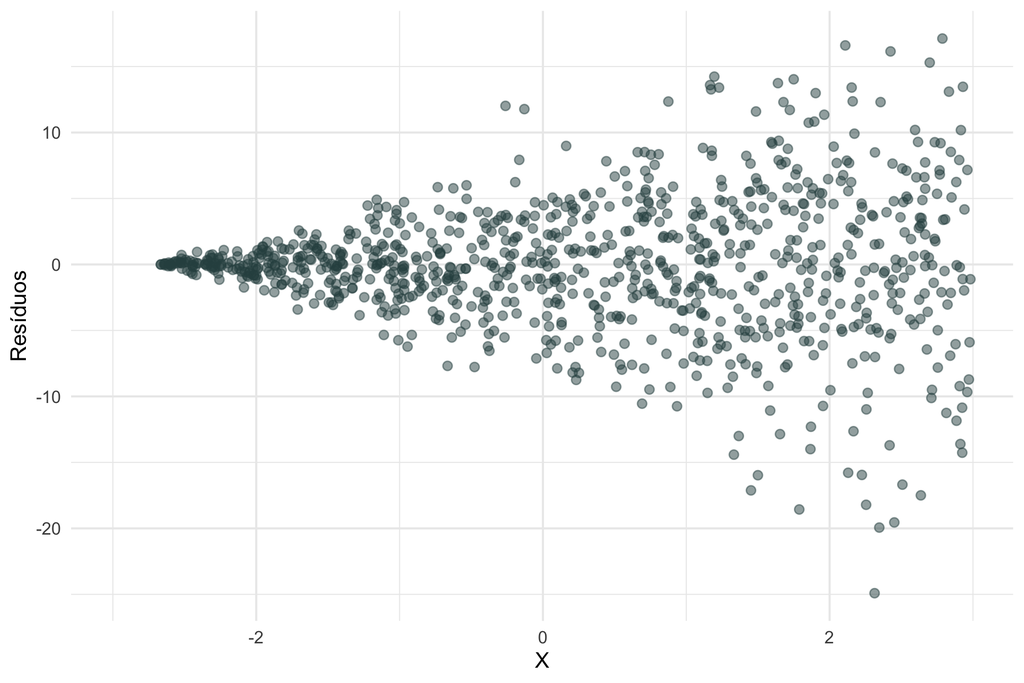

Exemlo clássico de heterocedasticidade. Variância do erro aumenta com $x$.

## Heterocedasticidade

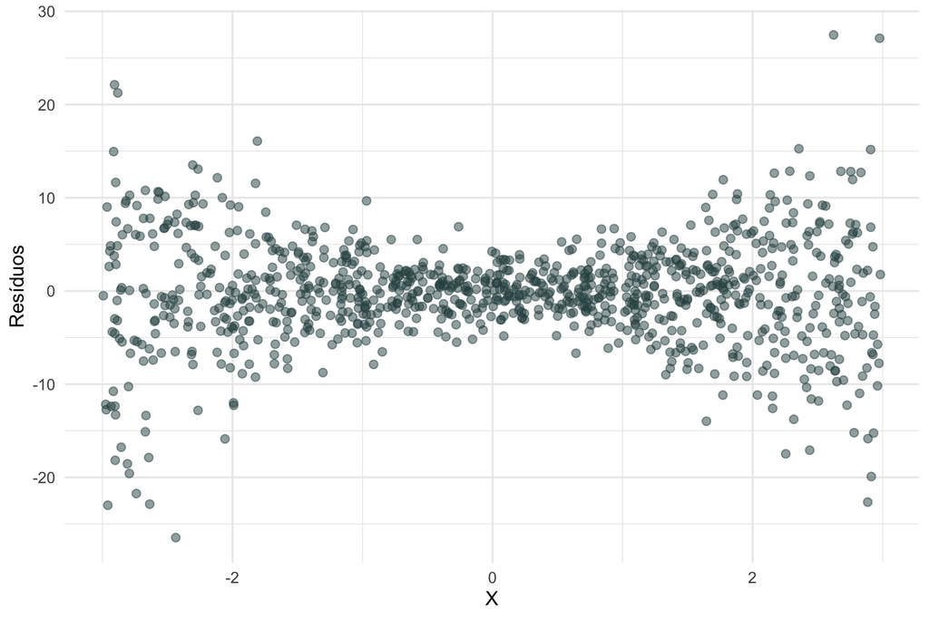

Outro exemplo de heterocedasticidade. Variância do erro aumenta nos extremos (funil duplo?).

## Heterocedasticidade

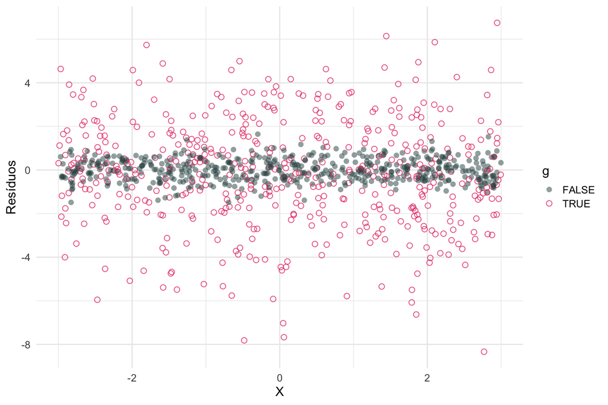

Outro exemplo de heterocedasticidade. Variâncias diferentes por grupo..

## Heterocedasticidade

**Consequências**

- Então, quais são as consequências da heterocedasticidade? Viés? Ineficiência?
- Primeiro, vamos verificar se há consequências para a ausência de viés do estimador de MQO.

**Lembrete<sub>1</sub>:** Os estimadores de MQO serem não viesados significa que $\mathop{\boldsymbol{E}}\left[ \hat{\beta}_k \middle| X \right] = \beta_k$ para todos os $k$.

**Lembrete<sub>2</sub>:** Anteriormente mostramos que $\hat{\beta}_1 = \dfrac{\sum_i\left(y_i-\overline{y}\right)\left(x_i-\overline{x}\right)}{\sum_i\left(x_i -\overline{x}\right)^2}$.

- Lembre-se que podemos reescrever este estimador como:

$$\hat{\beta}_1 = \beta_1 + \dfrac{\sum_i \left( x_i - \overline{x} \right) u_i}{\sum_i \left( x_i - \overline{x} \right)^2}$$

## Heterocedasticidade

**Consequências - Viés?**

- Agora queremos ver se a heterocedasticidade causa viés no estimador de MQO para $\beta_1$.

$$\begin{aligned}
\mathop{\boldsymbol{E}}\left[ \hat{\beta}_1 \middle| X \right]
&= \mathop{\boldsymbol{E}}\left[ \beta_1 + \dfrac{\sum_i\left(x_i - \overline{x}\right) u_i}{\sum_i\left(x_i -\overline{x}\right)^2} \middle| X \right] \\[0.5em]
&= \beta_1 + \mathop{\boldsymbol{E}}\left[ \dfrac{\sum_i\left(x_i - \overline{x}\right) u_i}{\sum_i\left(x_i -\overline{x}\right)^2} \middle| X \right] \\[0.5em]
&= \beta_1 + \dfrac{\sum_i\left(x_i - \overline{x}\right)}{\sum_i\left(x_i -\overline{x}\right)^2} \color{#e64173}{\underbrace{\mathop{\boldsymbol{E}}\left[ u_i \middle| X \right]}_{=0}} \\[0.5em]
&= \beta_1
\end{aligned}$$
- O estimador de MQO ainda é **não viesado** para $\beta_k$.

## Heterocedasticidade

**Descrição**

Lembre-se que o estimador da variância do erro de um modelo de regressão linear múltipla é:

$$\hat{\sigma}^2 = \frac{\hat{\boldsymbol{\epsilon}}'\hat{\boldsymbol{\epsilon}}}{T - k} = \frac{\left(\mathbf{y} - \mathbf{X}\hat{\boldsymbol{\beta}}\right)'\left(\mathbf{y} - \mathbf{X}\hat{\boldsymbol{\beta}}\right)}{T - k} = \frac{SQR}{T - k}$$

E que o estimador da matriz de variância-covariância dos parâmtetros desse modelo é:

$$\widehat{\mathrm{Var}}(\hat{\boldsymbol{\beta}}) = \hat{\sigma}^2 (\mathbf{X}'\mathbf{X})^{-1}$$

Portanto, se $\sigma^2$ não é constante, ou seja $\sigma_i^2 \neq \sigma^2$, então:

$$\widehat{\mathrm{Var}}(\hat{\boldsymbol{\beta}}) \neq \mathrm{Var}(\hat{\boldsymbol{\beta}})$$

## Heterocedasticidade

**Consequência - Eficiência**

Portanto, a **eficiência** e a **confiabilidade** da inferência sobre os estimadores de MQO não sobrevivem à heterocedasticidade:

- Na presença de heterocedasticidade, o estimador de MQO **não é mais** o mais eficiente (melhor) estimador linear não viesado (*BLUE*)

#### Ideia de uma possível “solução”

- Seria mais informativo (eficiente) **ponderar as observações** inversamente à variância dos $u_i$.
- Reduzir o peso dos $u_i$ com alta variância (contém muito ruido para fornecer informações confiáveis).
- Aumentar o peso das observações com $u_i$ de baixa variância (mais “confiáveis”).
- Agora temos uma ideia do método dos **Mínimos Quadrados Ponderados** (WLS).

## Heterocedasticidade

**Consequências - Inferência**

Os **erros padrão** dos estimadores MQO são **viesados** na presença de heterocedasticidade.

- Intervalos de confiança **incorretos**
- Problemas para testes de hipóteses (tanto testes **t** quanto **F**)
- É difícil aprender muito sem uma inferência sólida.

**Soluções:**

- **Testes** para determinar se há presença de heterocedasticidade.
- **Remédios** para eficiência e inferência.

# Testes de Heterocedasticidade

## Testando a Heterocedasticidade

**Testes**

Embora possamos ter soluções para a heterocedasticidade, a eficiência dos nossos estimadores depende da presença ou não de heterocedasticidade.

- O teste de **Goldfeld-Quandt**
- O teste de **Breusch-Pagan**
- O teste de **White**

Cada um desses testes se baseia no fato de que podemos **usar os resíduos do MQO** $\color{#e64173}{e_i}$ **para estimar o erro populacional** $\color{#e64173}{u_i}$.

## Teste de Goldfeld-Quandt

**Descrição**

- O teste de G-Q foi um dos primeiros testes de heterocedasticidade (Goldfeld e Quandt, 1965).
- Foca em um tipo específico de heterocedasticidade: se a variância de $u_i$ difere **entre dois grupos**

Lembra-se de como usamos os resíduos para estimar $\sigma^2$?

$$s^2 = \dfrac{\text{SQR}}{n-1} = \dfrac{\sum_i e_i^2}{n-1}$$

- Usaremos essa mesma ideia para determinar se há evidências de que os dois grupos diferem nas variâncias de seus erros, comparando efetivamente $s^2_1$ e $s^2_2$ dos dois grupos.

## Teste de Goldfeld-Quandt

**Algoritmo**

1. Ordene as observações pela variável explicativa $x$, que se suspeita estar associada à heterocedasticidade.
2. Exclua as observações centrais (por exemplo, o terço central).
3. Divida o restante dos dados em dois grupos:
   - $G_1$: observações com os menores valores de $x$,
   - $G_2$: observações com os maiores valores de $x$.
4. Estime regressões separadas de $y$ contra $x$ para cada grupo $G_1$ e $G_2$.
5. Calcule as somas dos quadrados dos resíduos (SQR) de cada grupo:
   - $SQR_1$: do grupo $G_1$
   - $SQR_2$: do grupo $G_2$
6. Calcule a estatística (F):

$$F = \frac{SQR_2 / (n_2 - k)}{SQR_1 / (n_1 - k)}$$

7. Compare com a distribuição $F_\{n_2 - k, n_1 - k\}$. Se valor-p é menor que 0.05, rejeita-se a hipótese nula de variância constante.

## Teste de Goldfeld-Quandt

**Estatística do Teste**

A estatística $F$ compara a variância dos resíduos entre dois grupos com diferentes valores da variável explicativa $x$:

$$F = \frac{\text{SSR}_2 / (n_2 - k)}{\text{SSR}_1 / (n_1 - k)}$$

- $\text{SSR}_1$, $\text{SSR}_2$: somas dos quadrados dos resíduos nos grupos 1 e 2.
- $n_1$, $n_2$: número de observações em cada grupo.
- $k$: número de parâmetros estimados (incluindo intercepto).

Sob a hipótese nula de homocedasticidade:

$$F \sim F_{n_2 - k,\, n_1 - k}$$

**Notas**

## Teste de Goldfeld-Quandt

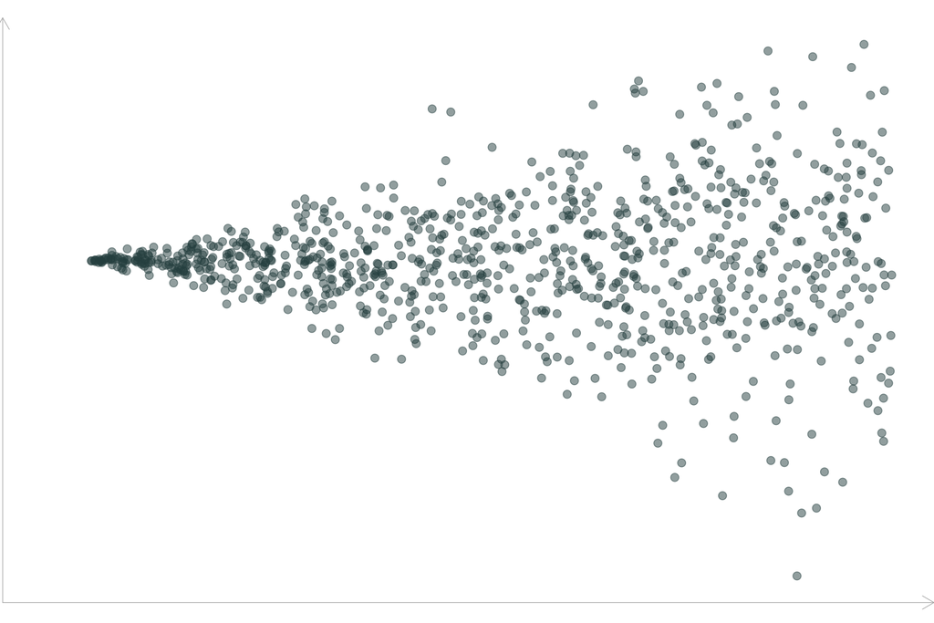

## Teste de Goldfeld-Quandt

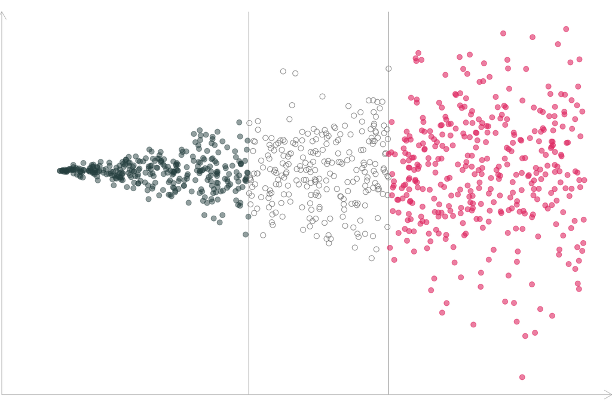

## Teste de Goldfeld-Quandt

**Caso aplicável**

$F_{375,\,375} = \dfrac{\color{#e64173}{\text{SQR}_2 = 18,203}}{\color{#314f4f}{\text{SQR}_1 = 1,039.5}} \approx 17.5 \implies$ valor-*p* $< 0.001$

- Portanto, rejeitamos $H_0$: $\sigma^2_1 = \sigma^2_2$ e e concluímos que há evidências estatisticamente significativas de heterocedasticidade.

## Teste de Goldfeld-Quandt - O Problema

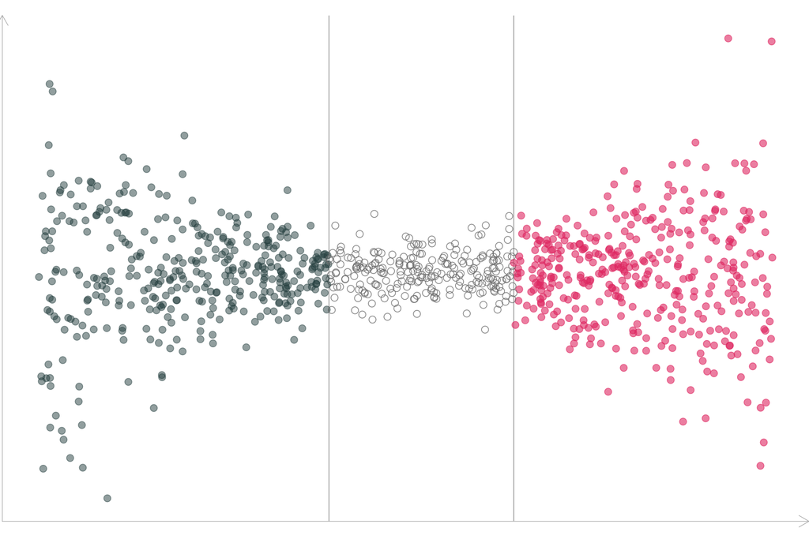

## Teste de Goldfeld-Quandt

**O Problema**

$F_{375,\,375} = \dfrac{\color{#e64173}{\text{SQR}_2 = 14,517}}{\color{#314f4f}{\text{SQR}_1 = 14,937}} \approx 1 \implies$ valor-*p* $\approx 0.609$

- Portanto, falhamos em rejeitar a $H_0$: $\sigma^2_1 = \sigma^2_2$, embora a heterocedasticidade esteja presente.

## Teste de Breusch-Pagan

**Descrição**

- Breusch e Pagan (1979) tentaram resolver o problema de ser excessivamente específico quanto à forma funcional da heterocedasticidade.

**Lógica do Teste:**

- Um teste que permita aos dados mostrarem se e como a variância de $u_i$ se correlaciona com $X$.
- Se $\sigma_i^2$ se correlaciona com $X$, então temos heterocedasticidade.
- Fazemos a regressão entre $e_i^2$ e $X = \left[ 1,\, x_1,\, x_2,\, \ldots,\, x_k \right]$ e testamos a significância conjunta.

## Teste de Breusch-Pagan

**Algoritmo**

1. Faça a regressão de $y$ contra um intercepto, $x_1$, $x_2$,…, $x_k$.
2. Registre os resíduos (e).
3. Faça a regressão de $e^2$ contra um intercepto, $x_1$, $x_2$,…, $x_k$.

$$e_i^2 = \alpha_0 + \alpha_1 x_{1i} + \alpha_2 x_{2i} + \cdots + \alpha_k x_{ki} + v_i$$

4. Registre $R^2$.
5. Teste a hipótese $H_0$: $\alpha_1 = \alpha_2 = \cdots = \alpha_k = 0$.

A estatística do teste de B-P é:

$$\text{LM} = n \times R^2_{e}$$

onde $R^2_e$ é o $R^2$ da regressão entre:

$$e_i^2 = \alpha_0 + \alpha_1 x_{1i} + \alpha_2 x_{2i} + \cdots + \alpha_k x_{ki} + v_i$$

Sob a hipótese nula, $\text{LM}$ é distribuída assimptoticamente como uma $\chi^2_k$.

Essa estatística de teste verifica $H_0\): \(\alpha_1 = \alpha_2 = \cdots = \alpha_k = 0$.

Rejeitar a hipótese nula implica evidências de heterocedasticidade.

## Valor-p do Teste de Breusch-Pagan

**valor-p:** probabilidade de observar uma estatística de teste $\widehat{\text{LM}}$ mais extrema sob $H_0$:

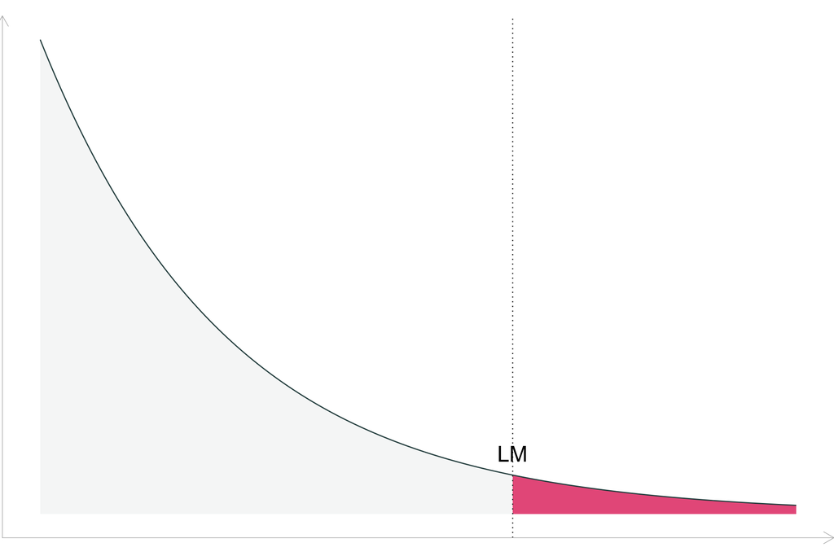

Disgtribuição de LM: dist. ui-quadrado com k graus de liberdade.

## Teste de Breusch-Pagan

**Problema**

**Problema:** Ainda estamos assumindo uma **forma funcional** bastante restritiva entre as variáveis explicativas (X) e as variâncias dos erros $\sigma^2_i$.

**Resultado:** O teste B-P *pode* ainda deixar de detectar formas relativamente simples de heterocedasticidade.

## Teste de Breusch-Pagan

Os testes de Breusch-Pagan ainda são **sensíveis à forma funcional**.

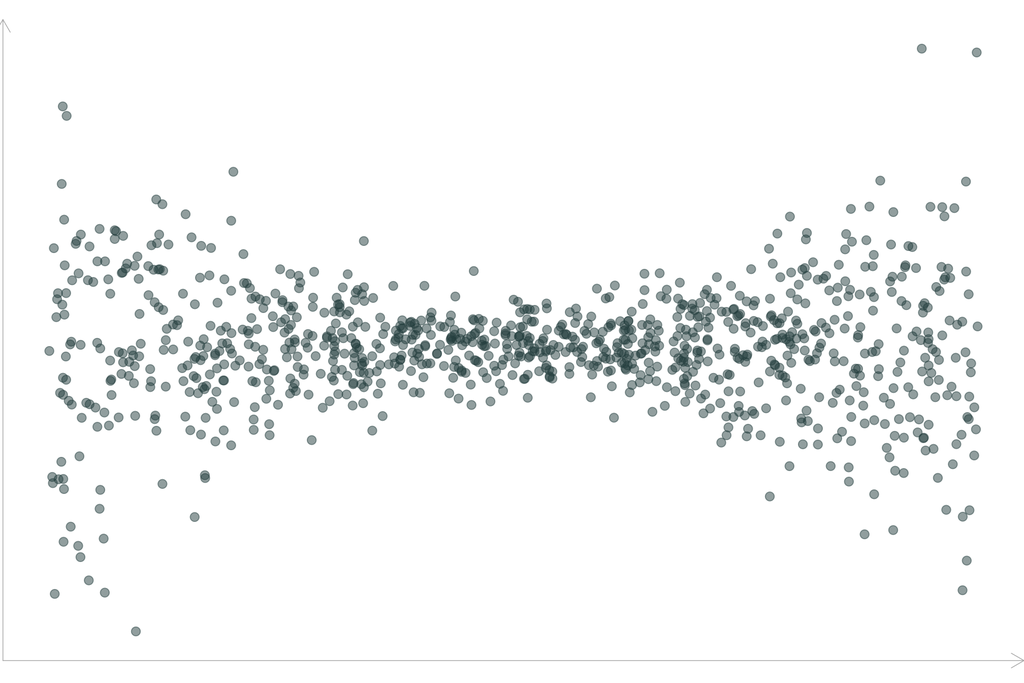

$$\begin{aligned}
e_i^2 &= \hat{\alpha}_0 + \hat{\alpha}_1 x_{1i} & \widehat{\text{LM}} &= 1.26 &\mathit{valor-}\text{p} \approx 0.261 \\
e_i^2 &= \hat{\alpha}_0 + \hat{\alpha}_1 x_{1i} \color{#e64173}{+ \hat{\alpha}_2 x^2_{1i}} & \widehat{\text{LM}} &= 185.8 &\mathit{valor-}\text{-p} < 0.001
\end{aligned}$$

## Teste de White

**Descrição**

Até agora, temos testado relações **específicas** entre as variáveis explicativas e as variâncias dos erros, *por exemplo*:

- $H_0$: $\sigma_1^2 = \sigma_2^2$ para dois grupos com base em $x_j$ (**G-Q**)
- $H_0$: $\alpha_1 = \cdots = \alpha_k = 0$ a partir de $e_i^2 = \alpha_0 + \alpha_1 x_{1i} + \cdots + \alpha_k x_{ki} + v_i$ (**B-P**)

No entanto, o que realmente queremos saber é se:

$$\sigma_1^2 = \sigma_2^2 = \cdots = \sigma_n^2$$

- **P:** Não podemos simplesmente testar essa hipótese?
- **R:** Mais ou menos.

## Teste de White

**Descrição**

Com esse objetivo, White (1980) aproveitou o fato de que podemos **substituir o requisito de homocedasticidade por uma suposição mais fraca**:

- **Antiga:** $V(u_i | X) = \sigma^2$
- **Nova:** $u^2$ *não é** correlacionado com as variáveis explicativas (*ou seja*, $x_j$ para todos os $j$), seus quadrados (*ou seja*, $x_j^2$) e as interações de primeira ordem (*ou seja*, $x_j x_h$).

Essa nova hipótese é mais fácil de testar explicitamente (*dica:* regressão).

## Teste de White

**Um Esboço do Teste de White**

1. Faça a regressão entre $y$ em $x_1$, $x_2$,…,$x_k$. Salve os resíduos $e$.
2. Faça a regressão entre os resíduos ao quadrado contra todas as variáveis explicativas, seus quadrados e interações:

$$e^2 = \alpha_0 + \sum_{h=1}^k \alpha_h x_h + \sum_{j=1}^k \alpha_{k+j} x_j^2 + \sum_{\ell = 1}^{k-1} \sum_{m = \ell + 1}^k \alpha_{\ell,m} x_\ell x_m + v_i$$

3. Registre $R_e^2$.
4. Calcule a estatística de teste para testar $H_0$: $\alpha_p = 0$ para todos os $p \neq 0$.

## Teste de White

**Descrição**

Assim como no teste de Breusch-Pagan, a estatística do teste de White é:

$$\text{LM} = n \times R_e^2 \qquad \text{Sob H}_0,\, \text{LM} \overset{\text{d}}{\sim} \chi_k^2$$

mas agora o $R^2_e$ vem da regressão entre $e^2$ e as variáveis explicativas, seus quadrados e suas interações.

$$e^2 = \alpha_0 + \underbrace{\sum_{h=1}^k \alpha_h x_h}_{\text{Variáveis explicativas}} + \underbrace{\sum_{j=1}^k \alpha_{k+j} x_j^2}_{\text{Termos ao quadrado}} + \underbrace{\sum_{\ell = 1}^{k-1} \sum_{m = \ell + 1}^k \alpha_{\ell,m} x_\ell x_m}_{\text{Interações}} + v_i$$

**Notas:**

- O $k$ (da dist. $\chi_k^2$) é igual ao número de parâmetros estimados na regressão acima (os $\alpha_j$), excluindo o intercepto $(\alpha_0)$.
- Se uma variável é igual ao seu quadrado (*por exemplo*, variáveis binárias), então não devemos (não podemos) incluí-la. A mesma regra se aplica para interações.

## Teste de White

**Exemplo**

Considere o modelo $y = \beta_0 + \beta_1 x_1 + \beta_2 x_2 + \beta_3 x_3 + u$.

**Passo 1:** Estime o modelo e obtenha os resíduos $(e)$.

**Passo 2:** Faça a regressão entre $e^2$ as variáveis explicativas, seus quadrados e interações:

$$\begin{aligned}
e^2 =
&\alpha_0 + \alpha_1 x_1 + \alpha_2 x_2 + \alpha_3 x_3 + \alpha_4 x_1^2 + \alpha_5 x_2^2 + \alpha_6 x_3^2 \\
&+ \alpha_7 x_1 x_2 + \alpha_8 x_1 x_3 + \alpha_9 x_2 x_3 + v
\end{aligned}$$

Registre o $R^2$ dessa equação (chame-o de $R_e^2$).

**Passo 3:** Teste $H_0$: $\alpha_1 = \alpha_2 = \cdots = \alpha_9 = 0$ usando $\text{LM} = n R^2_e \overset{\text{d}}{\sim} \chi_9^2$.

## Teste de White - Exemplo

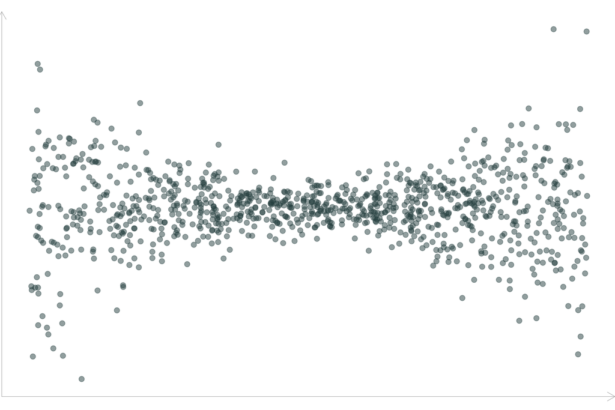

Já realizamos o teste de White para esta regressão linear simples.

$$\begin{aligned}
e_i^2 &= \hat{\alpha}_0 + \hat{\alpha}_1 x_{1i} \color{#e64173}{+ \hat{\alpha}_2 x^2_{1i}} & \widehat{\text{LM}} &= 185.8 &\mathit{valor}\text{-p} < 0.001
\end{aligned}$$

# Convivendo com a Heterocedasticidade

## Heterocedasticidade

**Revisão**

A **heterocedasticidade** está presente quando a variância de $u$ muda com qualquer combinação das variáveis explicativas $x_1$ até $x_k$.

Temos alguns testes que podem nos ajudar a detectar heterocedasticidade.

- Goldfeld-Quandt
- Breusch-Pagan
- White

O que fazemos se detectarmos a heterocedasticidade?

## Convivendo com a Heterocedasticidade

**Revisão**

Na presença de heterocedasticidade, os estimadores de MQO:

- ainda são **não viesados**.
- **não é** mais o estimador linear não viesado mais **eficiente**.

Em média, obtemos a resposta correta, mas com mais ruído (menos precisão).

*Também:* Os erros padrão são viesados.

**Opções:**

1. Verificar a **especificação** da regressão.
2. Encontrar um novo estimador **não viesado** mais eficiente para os $\beta_j$’s.
3. Conviver com a ineficiência dos estimadores de MQO; encontrar um **novo estimador da variância**.
   - Erros padrão
   - Intervalos de confiança
   - Testes de hipóteses

## Convivendo com a Heterocedasticidade

**Especificação Incorreta**

Como discutimos, a especificação do seu modelo de regressão importa muito para a não tendenciosidade e eficiência do estimador.

**Resposta nº 1:** Garanta que sua especificação não cause heterocedasticidade.

*Especificação:* Forma funcional e variáveis incluídas

## Convivendo com a Heterocedasticidade

**Especificação Incorreta**

*Exemplo:* Seja a relação populacional

$$y_i = \beta_0 + \beta_1 x_i + \beta_2 x_i^2 + u_i$$

com $\mathop{\boldsymbol{E}}\left[ u_i \middle| x_i \right] = 0$ e $\mathop{\text{Var}} \left( u_i \middle| x_i \right) = \sigma^2$.

No entanto, omitimos $x^2$ e estimamos:

$$y_i = \gamma_0 + \gamma_1 x_i + w_i$$

Então

$$w_i = u_i + \beta_2 x_i^2 \implies \mathop{\text{Var}} \left( w_i \right) = f(x_i)$$

*I.e.*, a variância de $w_i$ muda sistematicamente com $x_i$ (heteroscedasticidade).

## Convivendo com a Heterocedasticidade

Realidade: $\color{#e64173}{\log\left(y_i\right) = \beta_0 + \beta_1 x_i + u_i}$  
**Especificação Incorreta:** $\color{#314f4f}{y_i = \beta_0 + \beta_1 x_i + v_i}$

[figure not shown]

## Convivendo com a Heterocedasticidade

**Realidade:** $\color{#e64173}{\log\left(y_i\right) = \beta_0 + \beta_1 x_i + u_i}$  
Especificação Incorreta: $\color{#314f4f}{y_i = \beta_0 + \beta_1 x_i + v_i}$

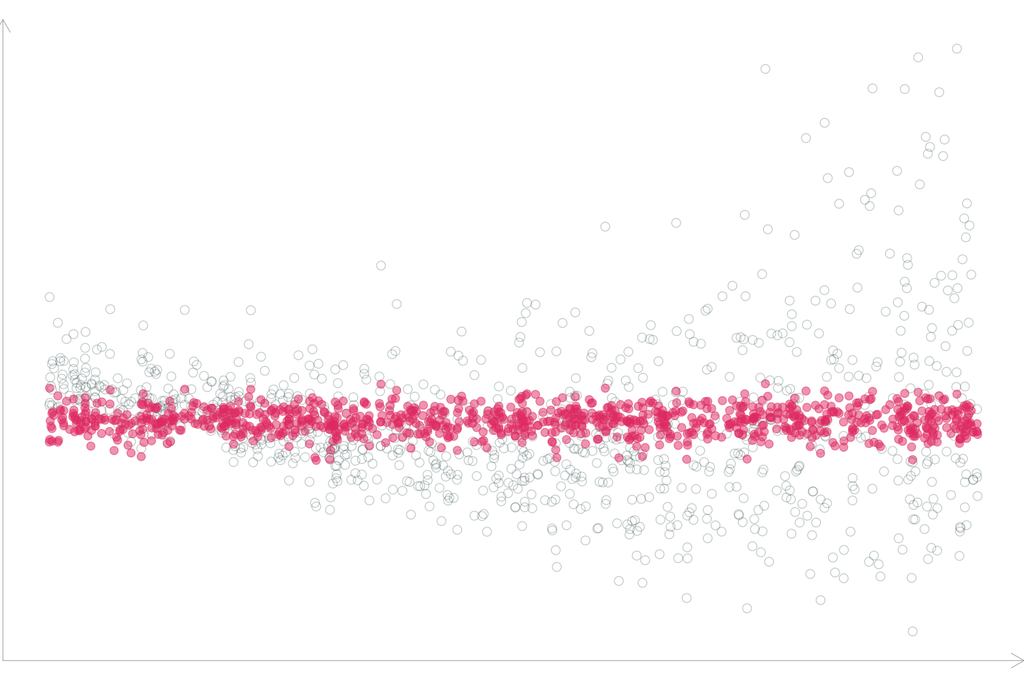

## Convivendo com a Heterocedasticidade

**Especificação Incorreta**

Mais geralmente:

**Problema de especificação incorreta:** A especificação incorreta do modelo de regressão pode causar heterocedasticidade (entre outros problemas).

**Solução:** não omita variáveis relevantes (*por exemplo*, não omita $x^2$).

**Novos problemas:**

- Muitas vezes não sabemos a especificação *correta*.
- Gostaríamos de um processo mais formal para abordar a heterocedasticidade.

**Conclusão:** A especificação muitas vezes não “resolverá” a heterocedasticidade.

No entanto, especificar corretamente o modelo ainda é muito importante.

## Convivendo com a Heterocedasticidade

*Weighted least squares* (WLS) (Mínimos Quadrados Ponderados)

Mínimos Quadrados Ponderados (WLS) apresentam outra abordagem.

**Resposta #2:** Aumente a eficiência ponderando as observações.

Seja a verdadeira relação populacional dada por:

$$\begin{align}
y_i = \beta_0 + \beta_1 x_{i} + u_i \tag{1}
\end{align}$$

com $u_i \sim \mathop{N} \left( 0,\, \sigma_i^2 \right)$.

Agora transforme $(1)$ dividindo os dados de cada observação por $\sigma_i$, *i.e.*,

$$\begin{align}
\dfrac{y_i}{\sigma_i} &= \beta_0 \dfrac{1}{\sigma_i} + \beta_1 \dfrac{x_{i}}{\sigma_i} + \dfrac{u_i}{\sigma_i} \tag{2}
\end{align}$$

## Convivendo com a Heterocedasticidade

*Weighted least squares* (WLS) (Mínimos Quadrados Ponderados)

$$\begin{align}
y_i &= \beta_0 + \beta_1 x_{i} + u_i \tag{1} \\[1em]
\dfrac{y_i}{\sigma_i} &= \beta_0 \dfrac{1}{\sigma_i} + \beta_1 \dfrac{x_{i}}{\sigma_i} + \dfrac{u_i}{\sigma_i} \tag{2}
\end{align}$$

Enquanto $(1)$ é heterocedástico, $\color{#e64173}{(2)}$ é **homocedástico**.

∴ MQO é eficiente e não viesado para estimar $\beta_k$ em $(2)$!

Por que $(2)$ é homocedástico?

$$\mathop{V} \left(\dfrac{u_i}{\sigma_i} \middle| x_i \right) =
\dfrac{1}{\sigma_i^2} \mathop{V} \left( u_i \middle| x_i \right) =
\dfrac{1}{\sigma_i^2} \sigma_i^2 = 1$$

## Convivendo com a Heterocedasticidade

*Weighted least squares* (WLS) (Mínimos Quadrados Ponderados)

WLS é ótimo, mas precisamos saber $\sigma_i^2$, o que geralmente é improvável.

Podemos relaxar *ligeiramente* esse requisito, requerendo que:

1. $\mathop{\text{Var}} \left( u_i | x_i \right) = \sigma_i^2 = \sigma^2 h(x_i)$
2. Sabemos $h(x)$.

Como antes, transformamos nosso modelo heterocedástico em um modelo homocedástico.

Desta vez, dividimos<sup>1</sup> os dados de cada observação por $\sqrt{h(x_i)}$.

[^1]: Divida *todos* os dados por $\sqrt{h(x_i)}$, incluindo o intercepto.

## Convivendo com a Heterocedasticidade

*Weighted least squares* (WLS) (Mínimos Quadrados Ponderados)

$$\begin{align}
y_i &= \beta_0 + \beta_1 x_{i} + u_i \tag{1} \\[1em]
\dfrac{y_i}{\sqrt{h(x_i)}} &= \beta_0 \dfrac{1}{\sqrt{h(x_i)}} + \beta_1 \dfrac{x_{i}}{\sqrt{h(x_i)}} + \dfrac{u_i}{\sqrt{h(x_i)}} \tag{2}
\end{align}$$

com $\mathop{\text{Var}} \left( u_i | x_i \right) = \sigma^2 h(x_i)$.

Agora vamos verificar se $(2)$ é de fato homocedástico.

$$\mathop{V} \left(\dfrac{u_i}{\sqrt{h(x_i)}} \middle| x_i \right) =
\dfrac{1}{h(x_i)} \mathop{V} \left( u_i \middle| x_i \right) =
\dfrac{1}{h(x_i)} \sigma^2 h(x_i) = \color{#e64173}{\sigma^2}$$

**Homocedasticidade!**

## Convivendo com a Heterocedasticidade

*Weighted least squares* (WLS) (Mínimos Quadrados Ponderados)

Estimadores de **Mínimos Quadrados Ponderados (WLS)** são uma classe especial de estimadores de **Mínimos Quadrados Generalizados (GLS)** focados em heterocedasticidade.

$$y_i = \beta_0 + \beta_1 x_{1i} + u_i \quad \color{#e64173}{\text{vs.}} \quad
\dfrac{y_i}{\sigma_i} = \beta_0 \dfrac{1}{\sigma_i} + \beta_1
\dfrac{x_{1i}}{\sigma_i} + \dfrac{u_i}{\sigma_i}$$
*Notas:*

1. WLS **transforma** um modelo heterocedástico em um modelo homocedástico.
2. **Ponderação:** WLS reduz o peso de observações com variância mais alta.
3. **Grande requisito:** WLS requer que *saibamos* $\sigma_i^2$ para cada observação.
4. WLS é geralmente **inviável** (*infeasible*). GLS *Feasible* (FGLS) oferece uma solução.
5. Sob suas suposições: WLS é o **melhor estimador linear não enviesado**.

## Convivendo com a Heterocedasticidade

**Erros Padrão Robustos à Heterocedasticidade**

**Resposta #3:**

- Ignore a ineficiência dos estimadores de MQO (na presença de heterocedasticidade).
- Foque em **estimativas não viesadas para os erros padrão**.
- No processo: Corrija a inferência.

**Q:** O que é erro padrão?

**R:** É o **desvio padrão da distribuição amostral de um estimador**.

Estimadores (como $\hat{\beta}_1$) são variáveis aleatórias, então eles têm distribuições de probabilidade.

Por convenção, o desvio-padrão da distribuição de probabilidade de um estimador recebe o nome de **erro-padrão** de um estimador.

## Convivendo com a Heterocedasticidade

**Erros Padrão Robustos à Heterocedasticidade**

*Lembre-se*: Podemos escrever o estimador de MQO para $\beta_1$ como:

$$\hat{\beta}_1 = \beta_1 + \dfrac{\sum_i \left(x_i - \overline{x} \right) u_i}{\sum_i \left( x_i - \overline{x} \right)^2}$$

Seja $\mathop{\text{Var}} \left( u_i \middle| x_i \right) = \sigma_i^2$.

$$\mathop{V} \left( \hat{\beta}_1 \middle| x_i \right) = \dfrac{\sum_i \left( x_i - \overline{x} \right)^2 \sigma_i^2}{(\sum_i \left(x_i - \overline{x} \right)^2)^2} \tag{4}$$

## Convivendo com a Heterocedasticidade

**Halbert White**

White (1980), é o artigo seminal de Halbert White, no qual ele propõe estimadores para obter erros padrão robustos à heterocedasticidade.

Este trabalho introduziu um estimador consistente para a matriz de covariância que é robusto à heterocedasticidade, permitindo que os erros padrão das estimativas sejam ajustados adequadamente na presença de variância não constante dos erros.

Além disso, White apresentou um teste direto para detectar heterocedasticidade, conhecido posteriormente como “Teste de White”.

Este artigo tornou-se uma das referências mais citadas em econometria, devido à importância prática dos estimadores e do teste proposto.

## Convivendo com a Heterocedasticidade

**Erros Padrão Robustos à Heterocedasticidade**

Se quisermos estimativas não viesadas para os erros padrão, precisamos de um estimador não viesado para:

$$\dfrac{\sum_i \left(x_i - \overline{x} \right)^2 \sigma_i^2}{(\sum_i \left(x_i - \overline{x} \right)^2)^2}$$

Halbert White (White, 1980) forneceu esse estimador<sup>1</sup>.

Ele demonstrou que sob condições bastante gerais:

$$\widehat{\mathop{\text{Var}}} \left( \hat{\beta}_1 \right)
= \dfrac{\sum_i \left(x_i - \overline{x} \right)^2 \hat{e}_i^2}{(\sum_i \left(x_i - \overline{x} \right)^2)^2}
\xrightarrow{p}
\mathop{\text{Var}} \left( \beta_1 \right)$$

onde os $\hat e_i$ são os resíduos da regressão de MQO de interesse.

Ou seja, White (1980) criou um estimador **consistente** para o erro-padrão dos estimadores de MQO na presença de variância não constante (isto é, na presença deheterocedasticidade).

[^2]: Esta equação específica é para regressão linear simples.

## Erros Padrão Robustos à Heterocedasticidade de White

```r
# Função para estimar erros-padrão robustos à heterocedasticidade (White, 1980)
# para regressão linear simples: y_i = beta0 + beta1 x_i + u_i
rls_hc0 <- function(y, x) {

  # Número de observações
  n <- length(y)

  # Médias amostrais
  ybar <- mean(y)
  xbar <- mean(x)

  # Estimativas dos coeficientes da regressão linear simples
  beta1hat <- sum((x - xbar) * y) / sum((x - xbar) * x)
  beta0hat <- ybar - beta1hat * xbar

  # Valores ajustados e resíduos
  yhat <- beta0hat + beta1hat * x
  ehat <- y - yhat

  # Estimador robusto de White (HC0) para Var(beta1hat)
  hc0 <- sum((x - xbar)^2 * ehat^2) / (sum((x - xbar)^2))^2

  # Erro-padrão robusto, estatística t e valor-p
  beta1hat_ep <- sqrt(hc0)
  beta1hat_t  <- beta1hat / beta1hat_ep
  beta1hat_p  <- 2 * pt(-abs(beta1hat_t), df = n - 2)

  # Exibição dos resultados
  cat("beta0hat:", round(beta0hat, 3), "\n")
  cat(
    "beta1hat:", round(beta1hat, 3),
    " e.p. (robusto à het.):", round(beta1hat_ep, 4),
    " stat-t:", round(beta1hat_t, 3),
    " val-p:", round(beta1hat_p, 4), "\n"
  )

  # Retorno como lista
  results <- list(
    beta0hat      = beta0hat,
    beta1hat      = beta1hat,
    beta1hat_se   = beta1hat_ep,
    ehat          = ehat,
    yhat          = yhat
  )

  return(results)
}
```

## Convivendo com a Heterocedasticidade

**Erros Padrão Robustos à Heterocedasticidade**

Os estimadores robustos à heterocedasticidade para o erro padrão de $\beta_j$ são:

**Caso 1** Regressão linear simples, $y_i = \beta_0 + \beta_1 x_i + u_i$

$$\widehat{\mathop{\text{Var}}} \left( \hat{\beta}_1 \right)
= \dfrac{\sum_i \left( x_i - \overline{x} \right)^2 \hat{e}_i^2}{\text{SST}_x^2}$$

**Caso 2** Regressão linear múltipla, $y_i = \beta_0 + \beta_1 x_{1i} + \cdots + \beta_k x_{ki} + u_i$

$$\widehat{\mathop{\text{Var}}} \left(\hat{\beta}_j \right) =
\dfrac{\sum_i \hat{r}_{ij}^2 \hat{e}_i^2}{\text{SST}_{x_j^2}}$$

onde $\hat{r}_{ij}$ denota o $i-$ésimo resíduo da regressão de $x_j$ contra todas as outras variáveis explicativas.

## Convivendo com a Heterocedasticidade

**Erros Padrão Robustos à Heterocedasticidade**

Com esses erros padrão, podemos retornar à inferência estatística correta.

*Por exemplo*, podemos atualizar a fórmula para a estatística $t$ anterior com os novos erros padrão robustos à heterocedasticidade:

$$t = \dfrac{\text{estimativa} - \text{valor hipotético sob H0}}{\text{erro-padrão robusto}}$$

## Convivendo com a Heterocedasticidade

**Erros Padrão Robustos à Heterocedasticidade**

**Notas**

- Ainda estamos usando os estimadores de MQO para $\color{#e64173}{\beta_j}$.
- Os erros padrão robustos à heteroc. usam um estimador diferente.
- Sob Homocedasticidade:
  - O estimador de MQO da variância é mais eficiente.
  - Os erros padrão robustos à heteroc. ainda são não viesados.
- Sob Heterocedasticidade:
  - O estimador de MQO da variância é viesado.
  - O estimador de variância robustos à heteroc. é não viesado.

## Convivendo com a Heterocedasticidade

**Erros Padrão Robustos à Heterocedasticidade**

Diversos estimadores consistentes para heterocedasticidade foram propostos na literatura desde o trabalho seminal de White (1980).

HC = *heteroskedasticity consistent*

#### White (1980)

$$HC0: \hat{e}_i^2$$

#### MacKinnon e White (1985)

$$HC1: \frac{n}{n - k}\hat{e}_i^2$$

$$HC2: \frac{\hat{e}_i^2 }{1 - h_i}$$

$$HC3: \frac{\hat{e}_i^2 }{(1 - h_i)^2}$$

#### Cribari-Neto (2004)

$$HC4: \frac{\hat{e}_i^2 }{(1 - h_i)^{\delta_i}}$$

#### Long e Ervin (2000)

Um estudo abrangente sobre o comportamento em pequenas amostras foi realizado por Long e Ervin (2000), que chegaram à conclusão de que o estimador **HC3** apresenta o melhor desempenho em amostras pequenas, pois atribui menor peso às observações influentes.

# H4: $\mathrm{Cov}(\varepsilon_i, \varepsilon_j \mid \mathbf{x}) = 0,\quad i \neq j$ erros não-correlacionados

## Autocorrelação nos erros

**Descrição**

- Uma das hipóteses do MRL é que $\mathrm{Cov}(u_i, u_j \mid \mathbf{x}) = 0,\quad$ para $i \neq j$.
- O modelo de regressão linear agora tem o subscrito $t$ para períodos de tempo:

$$Y_t = \beta_0 + \beta_1 X_t + u_t$$

- Nesse caso, mudamos a hipótese de exogeneidade para a hipótese de **exogeneidade contemporânea**, i.e, $E(u_t|X_t) = 0$

## Autocorrelação nos erros

**Descrição**

## Autocorrelação nos erros

**Descrição**

- Se há padrões nos resíduos de um modelo no tempo, dizemos que eles são autocorrelacionados.
- *Nota:* **Correlação serial** e **autocorrelação** são a mesma coisa.
- Alguns padrões estereotipados que podemos encontrar nos resíduos de um modelo de regressão linear com séries temporais são apresentados nos próximos 3 slides.

## Autocorrelação Positiva

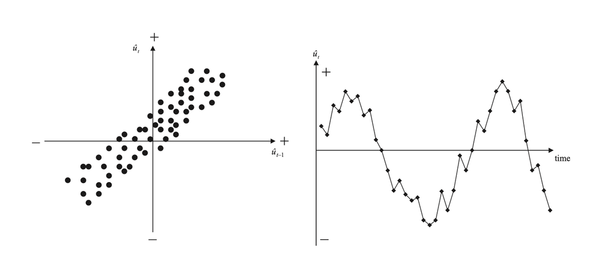

A autocorrelação positiva é indicada por um padrão cíclico dos resíduos ao longo do tempo.

## Autocorrelação Positiva

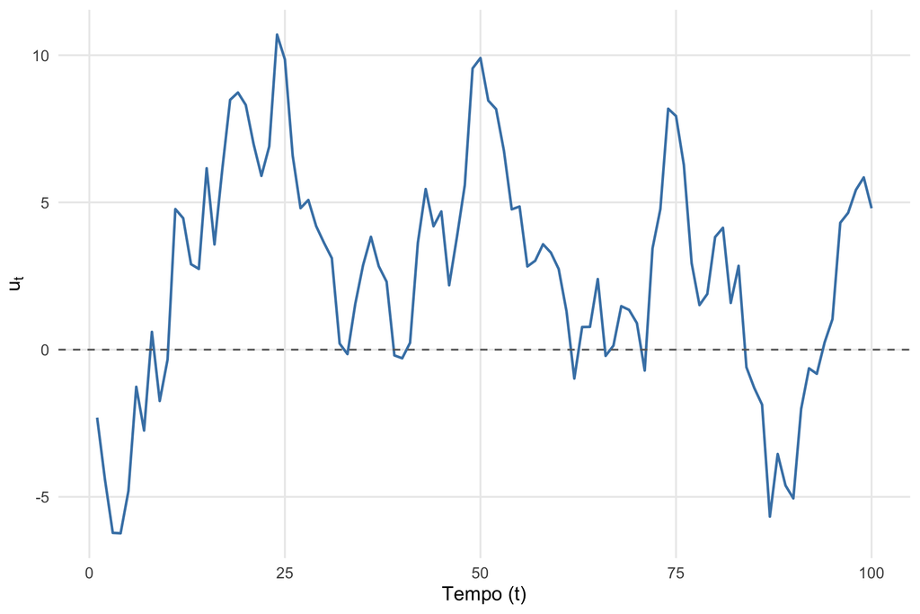

Simulação: erros com autocorrleação positiva no tempo (AR(1), ρ = 0.95).

## Autocorrelação Negativa

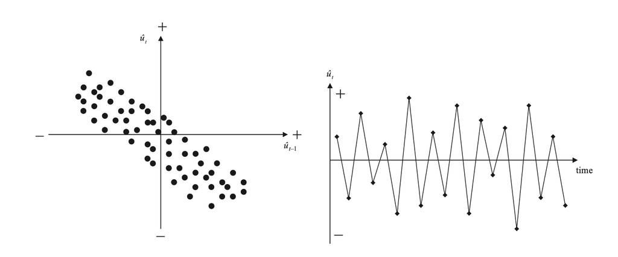

A autocorrelação negativa é indicada por um padrão alternado onde os resíduos cruzam o eixo do tempo com mais frequência do que se fossem distribuídos aleatoriamente.

## Autocorrelação Negativa

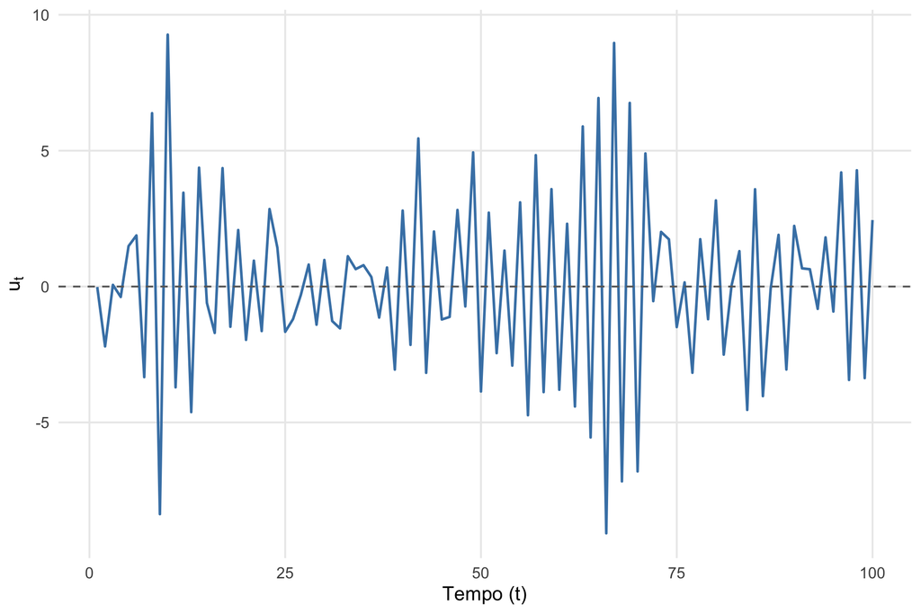

Simulação: erros com autocorrelação negativa no tempo (AR(1), ρ = -0.95).

## Sem Autocorrelação

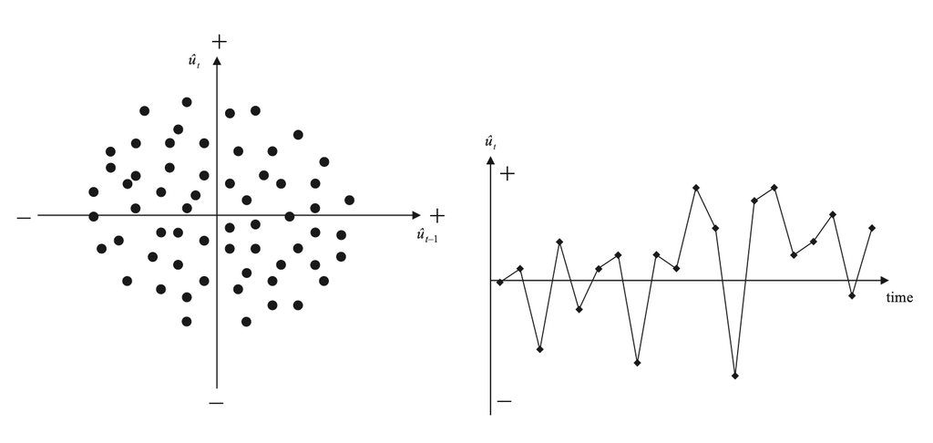

Nenhum padrão nos resíduos: é isso que gostaríamos de ver.

## Autocorrelação

**Consequências para os estimadores de MQO**

Para **modelos estáticos** ou modelos dinâmicos com variáveis explicativas defasadas, na presença de autocorrelação:

1. Os estimadores de MQO fornecem estimativas **não vieadas** dos parâmetros $\beta$.
2. Os estimadores de MQO fornecem estimativas **viesadas** para os erros-padrão dos parâmetros.
3. Os estimadores de MQO dos parâmetros são **ineficientes**

**Ou seja:** Mesmas implicações da heterocedasticidade.

- A autocorrelação fica mais complicada com a inclusão de variáveis resposta defasadas ($Y_{t-p}$).

## Autocorrelação

**Visão Moderna**

- Uma visão mais “moderna” sobre autocorrelação é que ela apresenta uma oportunidade em vez de um problema.
- Essa visão, associada a Sargan, Hendry e Mizon, sugere que a autocorrelação nos erros surge como uma consequência de **dinâmica mal especificada**.
- A autocorrelação nos resíduos seria frequentemente causada por uma estrutura dinâmica de $Y_t$ que não foi modelada.
- Em outras palavras, existe uma estrutura mais rica em $Y_T$ e mais informações na amostra sobre essa estrutura do que foi capturada pelos modelos tradicionais.
- O que seria necessário é um modelo dinâmico que permita essa estrutura extra em $Y_t$.

## Modelos de Regressão Linear com Séries Temporais

**Descrição**

Os modelos de regressão com séries temporais se resumem a duas classes de modelos:

- **Modelos Estáticos**: não permitem efeito persistente.
- Modelos **Dinâmicos**: permitem efeitos persistentes.
  - Modelos com Variáveis Explicativas Defasadas.
  - Modelos Autorregressivos com Defasagem Distribuída.
- *Nota:* Os modelos dinâmicos serão tratados na disciplina **Econometria II** (30 horas) que será ofertada em 2026-1 (primeiro bimestre de 2026).

## Por que desejamos/precisamos incluir defasagens em uma regressão?

**Principal Razão**

- **Inércia** em $Y_t$: Frequentemente, uma mudança no valor de uma das variáveis explicativas não afetará $Y_t$ imediatamente durante um período de tempo, mas sim com um atraso ao longo de vários períodos de tempo.
- Por exemplo, o efeito de uma mudança na microestrutura do mercado ou em uma política governamental pode levar alguns meses ou mais para funcionar, pois os agentes podem inicialmente não ter certeza de quais são as implicações para a precificação dos ativos, e assim por diante.

## Outras Causas de Autocorrelação nos Resíduos

**Possíveis Razões**

Entretanto, outros problemas com o modelo de regressão podem levar à rejeição da hipótese nula de ausência de autocorrelação, tais como:

- Erro de especificação como o uso de uma forma funcional inadequada.
- Omissão de variáveis relevantes que são autocorrelacionadas.
- Sazonalidade não modelada em $Y_t$

## Modelo Estático

**Descrição**

Os modelos de regressão linear com séries temporais **estáticos** assumem que a variável dependente ($y_t$) depende apenas do período atual:

$$\begin{align}
\text{y}_{\color{#e64173}{t}} = \beta_0 + \beta_1 \text{x}_{\color{#e64173}{t}} + u_{\color{#e64173}{t}}
\end{align}$$

- Aqui, devemos supor que $x_t$ afeta **imediatamente** $y_t$ e não afeta $y_t$ no futuro.
- Também precisamos supor que os $y_t$ atuais não dependem de $x_t$ anteriores.
- Pode ser uma maneira muito restritiva de considerar dados de séries temporais.
- Entretanto, ainda assim, modelos como APT, CAPM, etc. são comumente estimados como modelos estáticos.

## Modelos Dinâmicos

**1. Modelos com Defasagens Distribuídas**

- *Distributed Lag Models*

Esses modelos permitem que $Y_t$ dependa da(s) variável(eis) explicativa(s) ($X_t$) em outros períodos:

$$\text{Consumo}_{\color{#e64173}{t}} = \beta_0 + \beta_1 \text{Renda}_{\color{#e64173}{t}} + \beta_2 \text{Renda}_{\color{#6A5ACD}{t-1}} + \beta_3 \text{Renda}_{\color{#6A5ACD}{t-2}} + u_{\color{#e64173}{t}}$$

- Neste caso, a renda afeta imediatamente o consumo *e* afeta o consumo futuro.
- Em outras palavras: o consumo hoje depende da renda de hoje e das *defasagens* da renda (e.g: renda do mês passado ou renda do ano passado)
- Estimamos os efeitos *totais* somando os coeficientes das defasagens, *por exemplo*, $\beta_1 + \beta_2 + \beta_3$.
- **Nota**: Ainda assumimos que o consumo atual não afeta o consumo futuro.

## Modelos Dinâmicos

**2. Modelos Autorregressivos com Defasagens Distribuídas**

- *Autoregressive Distributed-Lag (ADL) Models*
- Esses modelos permitem que $Y_t$ dependa da(s) variável(eis) explicativa(s) ($X_t$) e/ou da variável resposta em períodos anteriores.

$$\begin{align}
\text{Consumo}_{\color{#e64173}{t}}
= &\beta_0 + \beta_1 \text{Renda}_{\color{#e64173}{t}} + \beta_2 \text{Renda}_{\color{#6A5ACD}{t-1}} + \beta_3 \text{Consumo}_{\color{#6A5ACD}{t-1}} + u_{\color{#e64173}{t}}
\end{align}$$

- Nesse caso, a renda atual afeta o consumo atual e o consumo futuro.
- Além disso, o consumo atual afeta o consumo futuro — estamos permitindo defasagens na variável resposta ($Y_{t-1}$).

## Modelo Estático

**Regressão Linear com Séries Temporais**

Vamos começar com um modelo muito comum: um modelo de regressão linear com séries temporais estático, cujos erros exibem **autocorrelação de primeira ordem**, também conhecido como AR(1):

$$\begin{aligned}
Y_t &= \beta_0 + \beta_1 X_t + u_t \\
u_t &= \phi u_{t-1} + \epsilon_t, \quad \epsilon_t \sim N(0, \sigma^2)
\end{aligned}$$
onde o termo de erro $u_t$ segue um processo autoregressivo de primeira ordem (AR(1)):

- $\phi$: Coeficiente de autocorrelação de primeira ordem (AR(1)).
- **autocorrelação de segunda ordem** (AR(2)) seria:

$$\begin{aligned}
\color{#6A5ACD}{u_t} = \color{#6A5ACD}{\rho_1 u_{t-1}} + \color{#6A5ACD}{\rho_2 u_{t-2}} + \varepsilon_t
\end{aligned}$$

## Modelo Estático

**Processo Autorregressivo AR(P)**

Um modelo/processo AR(p) tem uma estrutura de erros dada por:

$$\begin{align}
u_t = \sum_{j=1}^\color{#20B2AA}{p} \rho_j u_{t-j} + \varepsilon_t
\end{align}$$

permitindo que o erro atual seja correlacionado com até $\color{#20B2AA}{p}$ de suas defasagens (*lags*).

## Simulação

**Modelo de Regressão Linear Simples com Erros Autocorrelacionados**

Vamos simular um modelo de regressão liner simples estático, com erros autocorrelacionados, especificamente, os erros seguirão um processo autorregressivo de primeira ordem (AR(1)):

$$\begin{align*}
Y_t &= \beta_0 + \beta_1 X_t + u_t \\
u_t &= \phi u_{t-1} + \epsilon_t, \quad \epsilon_t \sim N(0, \sigma^2)
\end{align*}$$

Vamos simular um modelo com erros positivamente autocorrelacionados:

$$\begin{align*}
Y_t &= 2 + 0.5 X_t + u_t \\
u_t &= 0.9 u_{t-1} + \epsilon_t, \quad \epsilon_t \sim N(0, 1)
\end{align*}$$

## Código para a Simulação

```r
 # define o número de observações
n <- 200

# define os parâmetros da simulação
beta0 <- 2       # intercepto
beta1 <- 0.5    #  parâmetro da variável X
phi <- 0.9       # parâmetro de autocorrelação AR(1)
sigma <- 1       # desvio-padrão dos resíduos

# fixa a semente para reprodutibilidade
set.seed(123)

# simula x: uma variável com tendência
x <- 1:n + rnorm(n)

# inicializa o vetor de resíduos
u <- numeric(n)

# simula o primeiro resíduo
u[1] <- rnorm(1, mean = 0, sd = sigma)

# simula os resíduos autocorrelacionados (AR(1))
for (t in 2:n) {
  u[t] <- phi * u[t - 1] + rnorm(1, mean = 0, sd = sigma)
}

# simula y
y <- beta0 + beta1*x + u

# Converte x e y para uma série multivariada da classe ts
# frequency = 12 -> dados
dados_ts <- ts(cbind(x, y), start = c(1), frequency = 12)

# exibe as primeiras linhas
head(dados_ts)
```

```
#>             x      y
#> Jan 1 0.43952 4.4186
#> Feb 1 1.76982 6.1763
#> Mar 1 4.55871 6.9764
#> Apr 1 4.07051 7.0058
#> May 1 5.12929 6.8238
#> Jun 1 7.71506 7.4145
```

```r
# esibe as últimas linhas
tail(dados_ts)
```

```
#>             x      y
#> Mar 17 193.69 95.977
#> Apr 17 198.00 99.922
#> May 17 197.60 99.057
#> Jun 17 196.75 99.651
#> Jul 17 198.39 99.283
#> Aug 17 198.81 99.332
```

## Gráfico de Dispersão

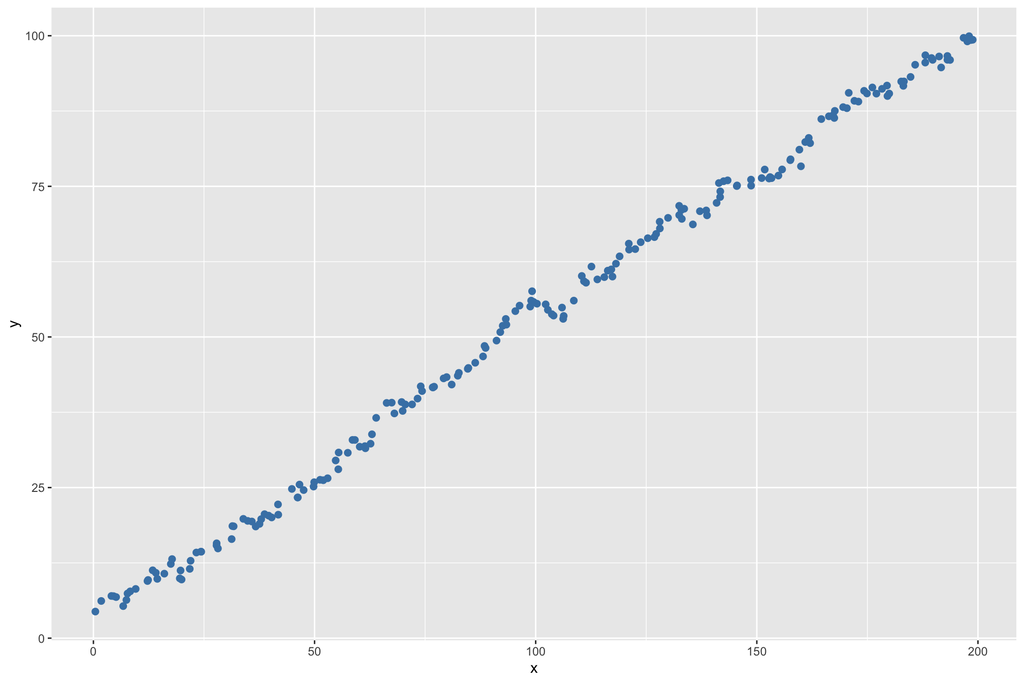

```r
# gráfico de dispersão do modelo simulado
ggplot(dados_ts, aes(x = x, y = y)) +
  geom_point(color = "steelblue", size = 2)
```

# Estimação de Modelos Estáticos

## Regressão Linear com Séries Temporais (Modelo Estático)

**Estimação com `lm()`**

A função `lm()` estima modelos estáticos, mas tem **limitações:**

- **não reconhece** a estrutura temporal.
- Lags, diferenças, tendência e sazonalidade exigem pré-processamento manual.

## Estimação com a função lm

```r
# Estimar o modelo estático
modelo_lm <- lm(y ~ x, data = dados_ts)

# resultado da estimação do modelo
summary(modelo_lm)
```

```
#>
#> Call:
#> lm(formula = y ~ x, data = dados_ts)
#>
#> Residuals:
#>    Min     1Q Median     3Q    Max
#> -3.886 -1.400 -0.032  1.213  5.474
#>
#> Coefficients:
#>             Estimate Std. Error t value            Pr(>|t|)
#> (Intercept)  3.00305    0.25181    11.9 <0.0000000000000002 ***
#> x            0.49514    0.00217   227.8 <0.0000000000000002 ***
#> ---
#> Signif. codes:  0 '***' 0.001 '**' 0.01 '*' 0.05 '.' 0.1 ' ' 1
#>
#> Residual standard error: 1.77 on 198 degrees of freedom
#> Multiple R-squared:  0.996,  Adjusted R-squared:  0.996
#> F-statistic: 5.19e+04 on 1 and 198 DF,  p-value: <0.0000000000000002
```

## Pacote `dynlm()`

**Função `dynlm()` do pacote dynlm**

A função `dynlm()` estende `lm()` para séries temporais, reconhecendo a estrutura temporal e permitindo a aplicação de operadores úteis para séries temporais.

**Vantagens principais:**

- Inclusão simples de **tendência temporal** com `trend(y)` (alinhada à série)
- Manipulação direta de **defasagens** com `L(var, k)`.
- Suporte nativo a objetos `ts`/`zoo`, com alinhamento temporal e tratamento automático de NAs induzidos por lags.

## Estimação com a função dynlm

```r
# carrega o pacote
library(dynlm)

# Estima o modelo estático usando dynlm com a série multivariada
modelo_dynlm <- dynlm(y ~ x, data = dados_ts)

# resultado da estimação do modelo
summary(modelo_dynlm)
```

```
#>
#> Time series regression with "ts" data:
#> Start = 1(1), End = 17(8)
#>
#> Call:
#> dynlm(formula = y ~ x, data = dados_ts)
#>
#> Residuals:
#>    Min     1Q Median     3Q    Max
#> -3.886 -1.400 -0.032  1.213  5.474
#>
#> Coefficients:
#>             Estimate Std. Error t value            Pr(>|t|)
#> (Intercept)  3.00305    0.25181    11.9 <0.0000000000000002 ***
#> x            0.49514    0.00217   227.8 <0.0000000000000002 ***
#> ---
#> Signif. codes:  0 '***' 0.001 '**' 0.01 '*' 0.05 '.' 0.1 ' ' 1
#>
#> Residual standard error: 1.77 on 198 degrees of freedom
#> Multiple R-squared:  0.996,  Adjusted R-squared:  0.996
#> F-statistic: 5.19e+04 on 1 and 198 DF,  p-value: <0.0000000000000002
```

## Resíduos do Modelo Estático

```r
# extrai os resíoduos do modelo
residuos <- resid(modelo_dynlm)

# gráfico dos resíduos contra o tempo
# gráfico de linha dos resíduos ao longo do tempo
plot(residuos,
     type = "l",
     main = "Resíduos ao longo do tempo",
     ylab = "Resíduos",
     xlab = "Tempo")
abline(h = 0, col = "red", lty = 2)
```

## Resíduos do Modelo Estático

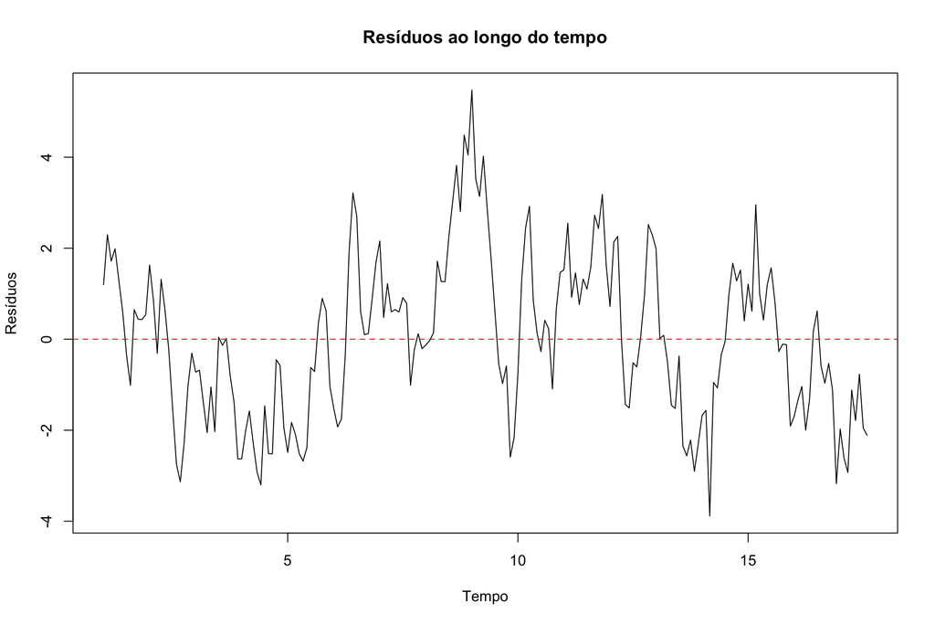

# Testes Para Autocorrelação

## Teste de Durbin-Watson

**Descrição**

- O teste de Durbin-Watson (Durbin e Watson, 1950) é um teste para autocorrelação de primeira ordem (AR(1)) nos resíduos
- Ou seja, o teste assume que a relação é entre o erro contemporâneo ($u_t$) e o erro do período anterior ($u_{t-1}$):

$$u_{t} = {\rho}u_{t - 1} + v_{t} \tag{1}$$

- Onde $v_t \sim N(0, \sigma_v^2)$.
- Assim, o teste de DW testa:

$$\text{H}_{0}:\rho = 0 \quad \text{vs.} \quad \text{H}_{1}:\rho \neq 0$$

- A estatística do teste é calculada por

$$\text{DW} = \frac{\sum_{t = 2}^T {\left( \hat{u}_t - \hat{u}_{t - 1} \right)^2}}{\sum_{t = 2}^T \hat{u}_t^2}$$
- **Importante:** A estatística do teste de DW não possui uma distribuição amostral exata (e conhecida) para todos os casos. Ela depende do número de variáveis explicativas, das suas correlações, do número de observacões. Somente se $n \to \infty$, a estatística do teste tende a seguir uma distribuição normal assintótica sob a hipótese nula.

**Condições que Devem Ser Satisfeitas para o Teste DW Ser Válido:**

1. Deve haver um intercepto na regressão
2. Variáveis explicativas ($X_t$) não estocásticas
3. Não deve haver defasagens (*lags*) de $Y_t$

## Teste de Durbin-Watson

**Descrição**

- Também podemos escrever

$$DW\, \approx \,2(1 - \hat {\rho }) \tag{2}$$

- Onde $\hat{\rho}$ é o coeficiente de correlação estimado. Como $\hat{\rho}$ é uma correlação, isso implica que $-1 \leq \hat{\rho} \leq 1$.
- Reorganizando a equação de a partir de (2), obtemos $0 \leq DW \leq 4$.
- Portanto, a estatística do teste de DW varia entre 0 e 4:

## Teste de Durbin-Watson

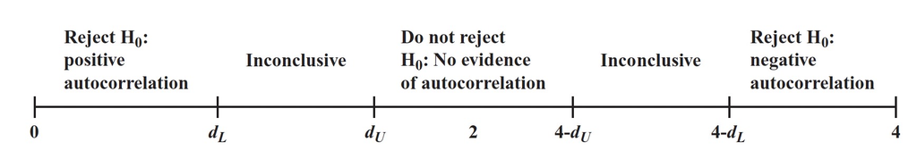

## Teste de Durbin-Watson

**Regras de Decisão**

- $DW \approx 0$: indica autocorrelação positiva (erros sucessivos tendem a ter o mesmo sinal).
- $DW \approx 2$: indica ausência de autocorrelação.
- $DW \approx 4$: indica autocorrelação negativa (erros sucessivos tendem a ter sinais opostos).
- Entretanto, existe também uma região intermediária onde não podemos rejeitar ou não rejeitar $H_{0}$.
- Esta região existe porque a estatística do teste Durbin-Watson não possui uma distribuição amostral exata (e conhecida) para todos os casos.

## Teste de Durbin-Watson em R

```r
# função dwtest do pacote lmtest
lmtest::dwtest(modelo_dynlm)
```

```
#>
#>  Durbin-Watson test
#>
#> data:  modelo_dynlm
#> DW = 0.332, p-value <0.0000000000000002
#> alternative hypothesis: true autocorrelation is greater than 0
```

**Resultado usando valor-p**

Como valor-p $\ll$ 0.05, os dados fornecem evidência para rejeitar a hipótese nula de ausência de autocorrelação, ao nível de significância de 5%, **como esperado**.

## Teste de Breusch-Godfrey

**Descrição**

O teste de Breusch e Godfrey (1978) é um teste mais geral da autocorrelação de p-ésima ordem:

$$\begin{align*}
e_t &= \rho_1 e_{t-1} + \rho_2 e_{t-2} + \cdots + \rho_p e_{t-p} + v_t \\
v_r &\sim N(0, \sigma_v^2)
\end{align*}$$

sendo $\rho_1, \rho_2, \dots, \rho_p$ os coeficientes de autocorrelação de diferentes ordens dos resíduos.

As hipóteses nula e alternativa do teste de Breusch-Godfrey são:

$$H_0: \rho_1 = 0 \, \text{e} \, \rho_2 = 0 \, \text{e} \, \cdots \rho_p = 0$$

$$H_A: \rho_1 \neq 0 \, \text{ou} \, \rho_2 \neq 0 \, \text{ou} \, \cdots \rho_p \neq 0$$
- ou seja, pelo menos um dos coeficientes de autocorrelação é diferente de zero.

- $p$ refere-se à ordem da autocorrelação que está sendo testada, e o valor de $p$ deve ser especificado pelo analista ao realizar o teste.

## Teste de Breusch-Godfrey

**Algoritmo**

- **Passo 1**: Estime o modelo de regressão original

$$y_t = \beta_0 + \beta_1 X_{1t} + \beta_2 X_{2t} + \dots + \beta_k X_{kt} + u_t$$

- **Passo 2**: Obtenha os resíduos $\hat e_t$ da regressão do passo 1.
- **Passo 3**: Regresse os resíduos $\hat e_t$ contra as variáveis explicativas do modelo original e contra $p$ defasagens dos resíduos:

$$e_t = \alpha_0 + \alpha_1 X_{1t} + \dots + \alpha_k X_{kt} + \rho_1 e_{t-1} + \rho_2 e_{t-2} + \dots + \rho_p e_{t-p} + v_t$$

o objetivo é testar a significância dos coeficientes das defasagens dos resíduos ($\rho_1, \dots, \rho_p$).

- **Passo 4**: Cálculo da estatística de teste $LM = n\times R_{aux}^2$

A estatística de teste é baseada no coeficiente de determinação $R^2$ da regressão auxiliar. A estatística é dada por:

$$LM = n \cdot R_{aux}^2$$

sendo $n$ o número de observações.

- **Distribuição Amostral da Estatística de Teste**:

Sob a hipótese nula $H_0$ (ausência de autocorrelação até a ordem $p$), a estatística $BG = n \cdot R_{aux}^2$ segue aproximadamente uma distribuição qui-quadrado ($\chi^2$) com $p$ graus de liberdade:

$$LM \sim \chi^2(p)$$

- **Valor-p pequeno (geralmente $< \alpha$)**: Se o valor-p for menor do que o nível de significância pré-determinado $\alpha$ (como $0,05$ ou $0,01$), rejeitamos a hipótese nula $H_0$.
- **Valor-p grande (geralmente $\geq \alpha$)**: Se o valor-p for maior ou igual ao nível de significância $\alpha$, não rejeitamos a hipótese nula $H_0$.

## Teste de Breusch-Godfrey em R

**Passo 1:** Estime o modelo estático ($y_t = \beta_0 + \beta_1 x_t + u_t$) com MQO

```r
reg_est <- lm(y ~ x, data = ar_df)
```

**Passo 2:** Adicione os resíduos ao conjunto de dados

```r
ar_df$e <- residuals(reg_est)
```

```r
reg_ar3 <- lm(e ~ lag(e) + lag(e, 2) + lag(e, 3), data = ar_df)
```

## Teste de Breusch-Godfrey em R

**Passo 4:** Calcule a estatística de teste $LM = n \cdot R_{aux}^2$ (que tem distribuição $\chi_k^2$), sendo $k$ o número de variáveis explicativas da regressão no passo 3 (aqui, $k = 3$)

```r
# extrai o R^2 da regressão auxiliar
r2_e <- summary(reg_ar3)$r.squared

# Calcula a estatística de teste: n vezes r2_e
lm_stat <- 100 * r2_e
lm_stat
```

```
#> [1] 72.382
```

Cálculo do valor-p:

```r
# Calcula o valor-p do teste
pchisq(q = lm_stat, df = 3, lower.tail = F)
```

```
#> [1] 0.0000000000000013185
```

## Teste de Breusch-Godfrey em R

```r
# função bgtest do pacote lmtest
# o argumento order define a ordem da autocorrelação que será testada
lmtest::bgtest(reg_est, order = 3)
```

```
#>
#>  Breusch-Godfrey test for serial correlation of order up to 3
#>
#> data:  reg_est
#> LM test = 72.2, df = 3, p-value = 0.0000000000000014
```

**Resultado usando valor-p**

Como valor-p $\ll$ 0.05, os dados fornecem evidência para rejeitar a hipótese nula de ausência de autocorrelação, ao nível de significância de 5%, também **como esperado**.

# Convivendo com Autocorrelação

## Convivendo com Autocorrelação

**Algoritmo**

Suponha que tenhamos evidências de que há heterocedasticidade e autocorrelação nos resíduos. O que podemos fazer?

Algumas opções são:

1. Verificar a Especificação do Modelo
2. Conviver com a ineficiência dos estimadores de MQO e encontrar um **novo estimador (consistente) da matriz de variâncias-covariâncias:** Erros padrão robustos à heterocedasticidade e àautocorrelação (Newey e West, 1987)).
3. Encontrar um novo estimador **não viesado:** Feasible Generalized Least Squares (FGLS)

## Convivendo com Autocorrelação

**Opção 1 - Especificação Incorreta**

- Especificação incorreta com autocorrelação é muito semelhante à nossa discussão com heterocedasticidade.
- Ao especificar incorretamente um modelo, podemos criar autocorrelação.
- Omitir variáveis que são correlacionadas ao longo do tempo fará com que os erros sejam correlacionadas ao longo do tempo.

## Convivendo com Autocorrelação

**Opção 1 - Especificação Incorreta**

**Exemplo:** Suponha que o consumo dependem da renda e do consumo anterior:

$$\begin{aligned}
\text{Consumo}_{t} = \beta_0 + \beta_1 \text{Consumo}_{t-1} + \beta_2 \text{Renda}_{t} + u_t
\end{aligned}$$

mas escrevemos o modelo como dependente apenas do consumo anterior, *ou seja*,

$$\begin{aligned}
\text{Consumo}_{t} = \beta_0 + \beta_1 \text{Consumo}_{t-1} + v_t
\end{aligned}$$
Assim, o erro $v_t$ é dado por:

$$v_t = \beta_2 \text{Renda}_t + u_t$$

que provavelmente é autocorrelacionado, já que a renda tende a ser correlacionada no tempo.

**Prova:**

Considere:

$$\begin{aligned}
v_{t} &= \beta_2 \text{Renda}_{t} + u_{t} \\
v_{t-1} &= \beta_2 \text{Renda}_{t-1} + u_{t-1}
\end{aligned}$$
Portanto:

$$\begin{aligned}
\text{Cov}(v_{t},\,v_{t-1}) &= \text{Cov}(\beta_2 \text{Renda}_{t} + u_{t},\, \beta_2 \text{Renda}_{t-1} + u_{t-1}) \\
&= \color{#e64173}{\text{Cov}(\beta_2 \text{Renda}_{t},\, \beta_2 \text{Renda}_{t-1})} + \text{Cov}(\beta_2 \text{Renda}_{t},\, u_t) + \\&
\text{Cov}(u_{t},\, \beta_2 \text{Renda}_{t-1}) + \text{Cov}(u_{t},\, u_{t-1}) \\
& \neq 0
\end{aligned}$$

Em geral, mesmo que $u_t$ seja exógeno e sem autocorrelação.

## Convivendo com Autocorrelação e Heterocedasticidade

**Opção 2 - Erros-padrão robustos à Heterocedasticidade e à Autocorrelação**

- Como no caso de heterocedasticidade, Newey e West (1987) propuseram um estimador consistente da matriz de variâncias-covariâncias dos parâmetros dos parâmetros na presença de heterocedasticidade e autocorrelação nos resíduos.
- O estimador de Newey-West é uma extensão do estimador de Huber-White, incorporando uma correção adicional para lidar com a autocorrelação dos erros.
- É recomendado utilizar esse estimador no caso de modelos estáticos, e de diversos outros modelos envolvendo séries temporais.
- A fórmula geral do estimador da matriz de covariância de Newey-West é dada por:

$$\hat{\Omega}_{NW} = X'(X'X)^{-1} \hat{S}_{NW} (X'X)^{-1}X$$

- $\hat{S}_{NW}$ é a matriz de covariância ajustada que incorpora tanto a variância dos resíduos quanto as autocovariâncias dos resíduos defasados, sendo dada por:

$$\hat{S}_{NW} = \sum_{t=1}^{T} \hat{u}_t^2 X_t X_t' + \sum_{l=1}^{q} \sum_{t=l+1}^{T} w_l (\hat{u}_t \hat{u}_{t-l} (X_t X_{t-l}' + X_{t-l} X_t'))$$

Onde:

- $\hat{u}_t$ são os resíduos estimados,
- $X_t$ é o vetor de regressores no período $t$,
- $w_l$ são os pesos de Bartlett, que decrescem linearmente com o número de defasagens $l$ e são dados por $w_l = 1 - \frac{l}{q+1}$,
- $q$ é o número máximo de defasagens, escolhido pelo pesquisador.
- A primeira soma trata da heterocedasticidade, e a segunda soma corrige a autocorrelação dos resíduos, aplicando os pesos $w_l$ para reduzir a contribuição das defasagens mais longas.
- Esse ajuste permite que a matriz de variâncias-covariâncias estimada seja robusta à presença de autocorrelação e heterocedasticidade.

## Erros-padrão de Newey-West em R

```r
# pacotes necessários
library(lmtest)   # função coeftest()
library(sandwich) # função NeweyWest()

# erros-padrão dos estimadores MQO
coeftest(modelo_dynlm)
```

```
#>
#> t test of coefficients:
#>
#>             Estimate Std. Error t value            Pr(>|t|)
#> (Intercept)  3.00305    0.25181    11.9 <0.0000000000000002 ***
#> x            0.49514    0.00217   227.8 <0.0000000000000002 ***
#> ---
#> Signif. codes:  0 '***' 0.001 '**' 0.01 '*' 0.05 '.' 0.1 ' ' 1
```

```r
# erros-padrão de Newey-West
coeftest(modelo_dynlm, vcov = NeweyWest(modelo_dynlm))
```

```
#>
#> t test of coefficients:
#>
#>             Estimate Std. Error t value             Pr(>|t|)
#> (Intercept)  3.00305    0.78616    3.82              0.00018 ***
#> x            0.49514    0.00607   81.56 < 0.0000000000000002 ***
#> ---
#> Signif. codes:  0 '***' 0.001 '**' 0.01 '*' 0.05 '.' 0.1 ' ' 1
```

## Convivendo com Autocorrelação

**Opção 3 - FGLS**

- Se não tivermos uma variável resposta defasada, então, o método Feasible Generalized Least Squares (FGLS) fornece estimadores dos erros padrão consistentes e eficientes.
- Considere modelo estático simples com os erros seguindo um AR(1):

$$\begin{align}
\text{Consumo}_t &= \beta_0 + \beta_1 \text{Renda}_t + u_t \tag{1} \\
u_t &= \rho u_{t-1} + \varepsilon_t \tag{2}
\end{align}$$

truque: Escreva $(1)$ para o período $t-1$ (e então multiplique por $\rho$)

$$\begin{align*}
\text{Consumo}_{t-1} &= \beta_0 + \beta_1 \text{Renda}_{t-1} + u_{t-1} \tag{3} \\
\rho \text{Consumo}_{t-1} &= \rho \beta_0 + \rho \beta_1 \text{Renda}_{t-1} + \rho u_{t-1} \tag{4}
\end{align*}$$

E agora subtraia $(4)$ de $(1)$:

$$\begin{align*}
\text{Consumo}_t - \rho \text{Consumo}_{t-1} =& \beta_0 \left( 1 - \rho \right) + \\
& \beta_1 \text{Renda}_t - \rho \beta_1 \text{Renda}_{t-1} + \\
& u_t - \rho u_{t-1}
\end{align*}$$

o que produz um modelo dinâmico muito específico:

$$\begin{align*}
\text{Consumo}_t =& \beta_0 \left( 1 - \rho \right) + \rho \text{Consumo}_{t-1} + \\
& \beta_1 \text{Renda}_t - \rho \beta_1 \text{Renda}_{t-1} + \\
& \color{#e64173}{\underbrace{u_t - \rho u_{t-1}}_{=\varepsilon_t}} \\
&= {\beta_0 \left( 1 - \rho \right) + \rho \text{Consumo}_{t-1} +} \\
&\beta_1 \text{Renda}_t - \rho \beta_1 \text{Renda}_{t-1} + \color{#e64173}{\varepsilon_t}
\end{align*}$$
- Este modelo transformado é livre de autocorrelação.

**P:** Como estimamos esse modelo? (Não sabemos $\rho$.)

**R:** Usando o método FGLS, é claro.

1. Estime o modelo original (não transformado); salve os resíduos.
2. Estime $\rho$: faça a regressão dos resíduos contra seus *lags* (sem intercepto).
3. Estime o **modelo transformado**, substituindo $\hat{\rho}$ por $\rho$.

# Outros tipos de autocorrelação

## Autocorrelação Espacial

**Autocorrelação Espacial**

- A autocorrelação pode ocorrer em dados envolvendo séries temporais, mas também em dados de seção-cruzada com uma dimensão espacial (**latitude** e **longitude** das unidades observacionais).

**Exemplo**: Se analisarmos a lucratividade de bancos em diferentes regiões, pode haver uma correlação espacial entre os resíduos de bancos da mesma região ou de regiões vizinhas.

> > “Tudo está relacionado com tudo o mais, mas coisas próximas estão mais relacionadas do que coisas distantes.” Waldo Tobler (1970)
- Mais detalhes podem ser encontrados em Anselin (1988).

## Referências

ANSELIN, L. **[Spatial Econometrics: Methods and Models](https://doi.org/10.1007/978-94-015-7799-1)**. Dordrecht: Kluwer Academic Publishers, 1988.

BREUSCH, T. S.; GODFREY, L. G. [A Review of Recent Work on Testing for Autocorrelation in Dynamic Econometric Models](https://doi.org/10.1111/j.1467-8454.1978.tb00635.x). **Australian Economic Papers**, v. 17, n. 31, p. 334–355, 1978.

BREUSCH, T. S.; PAGAN, A. R. A simple test for heteroscedasticity and random coefficient variation. **Econometrica**, v. 47, n. 5, p. 1287–1294, 1979.

BROOKS, C. **Introductory Econometrics For Finance**. 4th. ed. [s.l.] Cambridge University Press, 2019.

CRIBARI-NETO, F. Asymptotic Inference Under Heteroskedasticity of Unknown Form. **Computational Statistics & Data Analysis**, v. 45, p. 215–233, 2004.

DURBIN, J.; WATSON, G. S. [Testing for Serial Correlation in Least Squares Regression](https://doi.org/10.2307/2332391). **Biometrika**, v. 37, n. 3-4, p. 409–428, 1950.

GOLDFELD, S. M.; QUANDT, R. E. Some tests for homoscedasticity. **Journal of the American Statistical Association**, v. 60, n. 310, p. 539–547, 1965.

LONG, J. S.; ERVIN, L. H. [Using Heteroscedasticity Consistent Standard Errors in the Linear Regression Model](https://doi.org/10.1080/00031305.2000.10474549). **The American Statistician**, v. 54, p. 217–224, 2000.

MACKINNON, J. G.; WHITE, H. Some Heteroskedasticity-Consistent Covariance Matrix Estimators with Improved Finite Sample Properties. **Journal of Econometrics**, v. 29, p. 305–325, 1985.

NEWEY, W. K.; WEST, K. D. [A Simple, Positive Semi-Definite, Heteroskedasticity and Autocorrelation Consistent Covariance Matrix](https://doi.org/10.2307/1913610). **Econometrica**, v. 55, n. 3, p. 703–708, 1987.

WHITE, H. A heteroskedasticity-consistent covariance matrix estimator and a direct test for heteroskedasticity. **Econometrica**, v. 48, n. 4, p. 817–838, 1980.